# **Atividade Econometria- Problema Proposto**

[figure not shown]

Joseferson Da Silva Barreto

15/12/2021

# Objetivo

Realizar uma análise afim de solucionar o prblema descrito pelo contratante

## Questão proposta

Um engenheiro está interessado em investigar a resistência de uma nova fibra sintética usada na produção de camisas. Sabendo que a resistência é afetada pela quantidade de algodão usada na fibra, e que a quantidade desejada de algodão no produto final deve estar no intervalo de 10 a 40%, o engenheiro planeja um experimento com as seguintes quantidades de algodão: 15, 20, 25, 30 e 35%, e cinco repetições.Dados de resistência (em libras/pol2) para o experimento de fibra sintética.

| nivel de algodão | observação1 | observação2 | observação3 | observação4 | observação5 |
| --- | --- | --- | --- | --- | --- |
| 15% | 7 | 7 | 15 | 11 | 9 |
| 20% | 12 | 17 | 12 | 18 | 18 |
| 25% | 14 | 18 | 18 | 19 | 19 |
| 30% | 19 | 25 | 22 | 19 | 23 |
| 35% | 7 | 10 | 11 | 15 | 11 |

## Primeiro passo

O primeiro passo é comprender o problema proposto ? oque eu quero ? quais formas possíveis para solucionar esse problema?

bom ,uma primeira abordagem sobre nossos dados nos leva a crer que a realização de um DIC(**Delineamento Inteiramente Casualisado**) seja uma boa saída para resolução do problema , tendo em vista que estamos falando de um experimento onde foram utilizadas 5 repetições

## As nossas hipóteses de estudo serão:

### Quanto maior a quantidade de nível de algodão ,maior será a resistencia do tecido

### indentificar a quantidade de fibra ideal de obtenção de máxima resistencia pelo o menor custo .

# chamando o banco de dados sobre os níveis de fibra de algodão

Para está analise será utilizado o pacote **ExpDes.pt**, para carregamento do banco de dados utlizaremos o pacote **readxl**.

```r
library(ExpDes.pt)
library(readxl)
algodao<-read_excel("C:/Users/josef/Documents/nova atividade de econometria/eco_nivelagudão.xlsx")




attach(algodao)



resp=c(7,7,15,11,9,12,17,12,
       18,18,14,18,18,19,19,
       19,25,22,19,23,7,10,11,15,11)


trat=factor(rep(1:5,each=5),labels = c("15%","20%","25%","30%","35%"))


niv<-data.frame(trat,resp)
data.frame(trat,resp) %>% datatable()
```

|  | trat | resp |
| --- | --- | --- |
| 1 | 15% | 7 |
| 2 | 15% | 7 |
| 3 | 15% | 15 |
| 4 | 15% | 11 |
| 5 | 15% | 9 |
| 6 | 20% | 12 |
| 7 | 20% | 17 |
| 8 | 20% | 12 |
| 9 | 20% | 18 |
| 10 | 20% | 18 |

[output cut: 15 more lines]

# visualizando

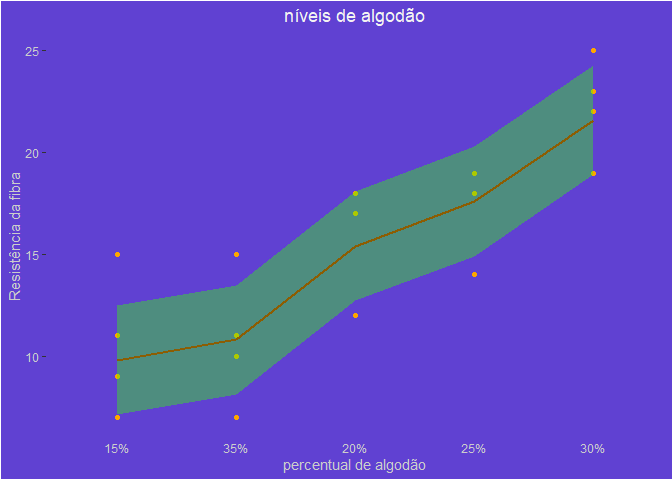

# Criando o nosso modelo

Para criar o nosso modelo vamos utlizar a função **aov()** do pacote Stats, em sequência , utilizaremos o comando **Summary** para montagem do quadro da váriancia , popurlamente conhecido como quadro da Anova .

```r
mod<-aov(resp~trat)

summary(mod)
```

|  | . | Df | Sum | Mean | Sq | Pr..F. | . |
| --- | --- | --- | --- | --- | --- | --- | --- |
| 1 | trat | 4 | 475.8 | 118.94 | 14.76 | 9.13e-06*** |  |
| 2 | residuals | 20 | 161.2 | 8.06 |  |  |  |
| 3 | signific.codes | 0'***' | 0.001'**' | 0,01'*' | 0,05' | 0,1' | 1 |

### hipóteses da Anova

$H_0 :$ Não existe diferença entre os tratamentos para $P \ge 0,05$

$H_1 :$ ao menos um dos tratamentos diferem entre si $P < 0,05$

como podemos analisar o Pvalor que é resultado da comparação do valor F encontrado com os dados do experimento com o Ftabelado , ou seja , o R pega o valor encontrado de F e compara com o valor do Fpadrão(Ftabelado) considerando o nível de significancia de 5% e como podemos observar ,nosso Pvalor é menor que 0,05% ,logo, pelo menos um dos tratamentos diferem entre sí há 95% de confiança.

# Análise dos resíduos

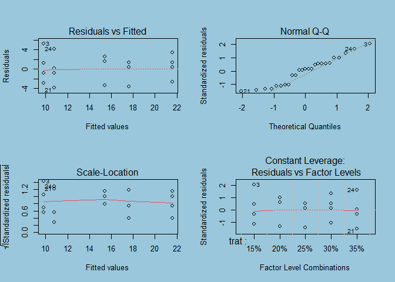

```r
par(bg = '#9ac7db')
par(mfrow=c(2,2))
plot(mod)
```

Os resíduos pelo os valores previstos , ele nos permite observar tanto a linearidade quanto a homocedasticidade , mas como verificamos se de fato o modelo é linear ? nos conseguimos a resposta olhando a linha vermelha traçada nesse primeiro gráfico(**Residuals Vs Fited**) , caso a linha vermelha esteja aparentimente horizontal então temos a linearidade , logo , em osso caso esse presuposto foi atendido. Outro ponto a se observar nesse gráfico é a homocedasticidade que nada mais é que a homogenidade das variâncias , caso exista homogenacidade nos dados veremos a dispersão dos pontos de forma aproximadamente constante ao longo dos valores previstos de Y(que está no eixo X),ou seja , teriamos uma dispersão aproximadamente regular em forma de retângulo ao longo do gráfico ,perceba que esse é o nosso caso.Caso não exitesse homogenidade nos dados os valores formariam uma espécie de triângulo no gráfico.

**normal QQ=** é o gráfico que nos permite ver sé os resíduos seguem distribuição normal , onde no eixo Y estão os resíduois padronizados e no eixo X os resíduos teóricos que seriam os resíduos esperados caso a distribuição fosse normal , para que os nosssos dados siga uma distruição normal , os valores devem estar em cima da linha pontilhada , embora nem todos estejam em cima da linha , podemos considerar que está apróximadamente normal, caso não fosse atendido , estes pontos aprensentaria um formato de curva .

**Scale_Location =** é o gráfico mais recomendado para ver a homogenacidade , caso exista homogenacidade a linha vermelha deve estar aproximadamente horizontal , que é nosso casso

**Residuals vs factor levals=**Pode ser útil para detectar a presença de pontos influenciantes. No nosso caso, não temos presença de infuenciadores, umas vez que a linha vermelha, a qual indica essa presença, tem como valor de resíduo igual a zero.

# Realizando o dic

```r
dic(trat, resp ,mcomp = "tukey")
```

[output not shown]

essa linha de comando irá nos retonar várias analises como: **anova**(já observada anteriormente),**CV**(coeficiente de variação), que nesse caso foi de 18% : $CV=18$%, além dos testes :(**teste de normalidade dos residuos (Shapiro-Wilk)**,**Teste de homogeneidade de variancia(bartlett)** e **Teste de Tukey**). Agora vamos observar cada um desses Testes e tomar a nossa conclusão:

# Teste de normalidade dos residuos ( Shapiro-Wilk )

Vamos começar analisando o resultado do teste de normalidade de resíduos(Shapiro-Wilk)

## hipóteses:

$H_0 :$ existe normalidade nos resíduos para $P \ge 0,05$

$H_1 :$ não existe normalidade dos resíduos $P < 0,05$

| Teste de normalidade dos residuos ( Shapiro-Wilk ) | valor-p |
| --- | --- |
| Valor-p | 0.1817575 |

De acordo com o teste de Shapiro-Wilk a 5% de significancia,não rejeita-se a hipótese nula,logo, os residuos podem ser considerados normais.

# Analisando o resultado do teste de homogenidade(bartlett)

## hipóteses:

$H_0 :$ existe homogenidade na variância para $P \ge 0,05$

$H_1 :$ não existe homogenidade na variância $P < 0,05$

| Teste de homegenidade de variancia | valor-p |
| --- | --- |
| Valor-p | 0.9197662 |

De acordo com o teste de bartlett a 5% de significancia, não rejeitace a hipótese nula, logo, as variancias podem ser consideradas homogeneas.

# Analisando o teste Tukey

vamos analisar o quadro de médias do teste Tukey

```r
Medias=c(21.6,17.6,15.4,10.8,9.8)


Grupos=factor(rep(1:5,each=1),labels = c("a","ab","bc","cd","d"))
Tratamentos=factor(rep(1:5,each=1),labels = c("30%","25%","20%","35%","15%"))

niv2<-data.frame(Grupos,Tratamentos,Medias)



niv2 %>% datatable()
```

|  | Grupos | Tratamentos | Medias |
| --- | --- | --- | --- |
| 1 | a | 30% | 21.6 |
| 2 | ab | 25% | 17.6 |
| 3 | bc | 20% | 15.4 |
| 4 | cd | 35% | 10.8 |
| 5 | d | 15% | 9.8 |

Como podemos observar a fibra sintética com 30% de algodão obteve a melhor resistência , entretanto , entre a fibra sintética de 25% e a fibra de 30% não tivemos uma diferença significativa , ou seja , são estatisticamente iguais os resultado , logo a fibra que tem uma máxima resistência por um menor custo é a fibra sintética com 25% de algodão .

# Conclusão

Após as análises estatísticas foi constatado que a fibra Sintética com 25% de algodão foi a que obteve a máxima resistência com menor custo do produto final.

# Acesse meus outros projetos :

Relatório sobre os testes paramétricos e não paramétricos :

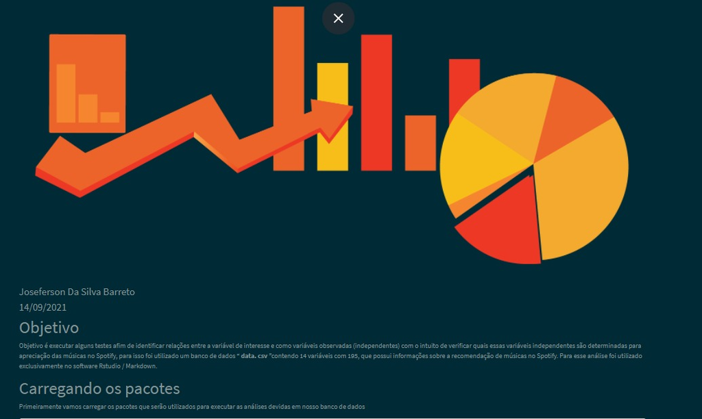

Análise Exploratória na linguagem Python :

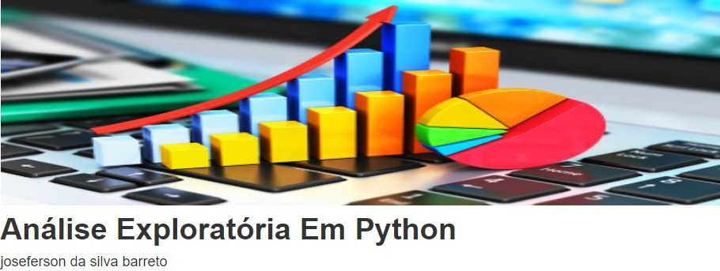

Econometria-Regressão Multipla :

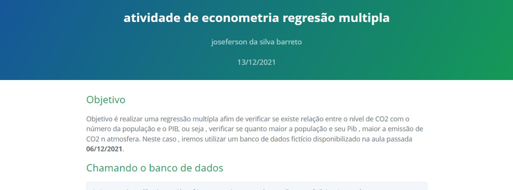